# Intro to Discrete-Time Survival Analysis in R

Qixiang Fang and [Rens van de Schoot](https://www.rensvandeschoot.com/about-rens/)

Last modified: date: 28 August 2019

This tutorial provides the reader with a hands-on introduction to discrete-time survival analysis in R. Specifically, the tutorial first introduces the basic idea underlying discrete-time survival analysis and links it to the framework of generalised linear models (GLM). Then, the tutorial demonstrates how to conduct discrete-time survival analysis with the `glm` function in R, with both time-fixed and time-varying predictors. Some popular model evaluation methods are also presented. Lastly, the tutorial briefly extends discrete-time survival analysis with multilevel modelling (using the `lme4` package) and Bayesian methods.

This tutorial follows this structure:  
1. Preparation  
2. Introduction to Discrete-Time Survival Analysis  
3. Data “Scania”: Old Age Mortality in Scania, Southern Sweden  
4. Data Preparation  
5. Gompertz Regression  
6. Model Evaluation: Goodness-of-Fit  
7. Model Evaluation: Predictive Performance  
8. Multilevel Discrete-Time Survival Analysis  
9. Bayesian Discrete-Time Survival Analysis

Note that this tutorial is meant for beginners and therefore does not delve into very technical details or complex models. For a detailed introduction into GLM or multilevel models in R, see [Online Stats Training](https://www.rensvandeschoot.com/tutorials/). For an extensive overview of GLM models, see [here](https://en.wikipedia.org/wiki/Generalized_linear_model). For more discrete-time survival analysis, check out [Modeling Discrete Time-to-Event Data](https://www.springer.com/gp/book/9783319281568) by Tutz & Schmid (2016). For more multilevel modelling, see [Multilevel analysis: Techniques and applications](https://www.rensvandeschoot.com/multilevel-book/).

## **1. Preparation**

This tutorial expects:  
- Installation of R package [`tidyverse`](https://cran.r-project.org/web/packages/tidyverse/index.html) for data manipulation and plotting with ggplot2;  
- Installation of R package [`haven`](https://cran.r-project.org/web/packages/tidyverse/index.html) for reading sav format data;  
- Installation of R packages [`lme4`](https://cran.r-project.org/web/packages/lme4/index.html) for multilevel modelling (this tutorial uses version 1.1-18-1);  
- Installation of R package [`jtools`](https://cran.r-project.org/web/packages/jtools/index.html) for handling of model summaries;  
- Installation of R package [`effects`](https://cran.r-project.org/web/packages/effects/index.html) for plotting parameter effects;  
- Installation of R package [`eha`](https://cran.r-project.org/web/packages/eha/index.html), which contains the data set we will use;  
- Installation of R package [`discSurv`](https://cran.r-project.org/web/packages/discSurv/index.html), for discrete-time data manipulation and calculation of prediction error curves;  
- Basic knowledge of hypothesis testing and statistical inference;  
- Basic knowledge of generalised linear models (GLM);  
- Basic knowledge of coding in R;  
- Basic knowledge of plotting and data manipulation with tidyverse.

## **2. Introduction to Discrete-Time Survival Analysis**

Read More

The next section details the exampler data (**Scania Data**) in this tutorial, followed by a demonstration of Gompertz regression and a brief introduction to its multilevel and Bayesian extension.

## **3. Data “Scania”: Old Age Mortality in Scania, Southern Sweden**

The data used in this tutorial is `Scania`, offered by The Scanian Economic Demographic Database (Lund University, Sweden). The data consists of old-age life histories from 1 January 1813 to 31 December 1894 in Scania, Southern Sweden. Only life histories above age 50 are included. The data set has 9 variables (not all will be considered in this study). They are:

`id`: identification number of the person;  
`enter`: start age of the person (beginning time interval);  
`exit`: stop age of the person (cencored/final time interval);  
`event`: indicator of death at a corresponding time interval;  
`birthdate`: birthdate of the person;  
`sex`: gender, a factor with levels “male” and “female”;  
`parish`: one of five parishes in Scania, factor variable;  
`ses`: socio-economic status at age 50, a factor with levels “upper” and “lower”;  
`immigrant`: a factor with levels “no” and “yes”.

This data set comes with the R package `eha`. Note that in this data set, there is no time-varying predictor. Therefore, we will manually add a time-varying variable “foodprices” from the “logrye” data set that is also available in the `eha` package. “logrye” consists of yearly rye prices from 1801 to 1894 in Scania. Rye prices are used as an indicator for food prices.

The main research question that this tutorial seeks to answer using the “Scania” data is: *What are the effects of gender, socio-economic status, immigrant status, and food prices on a person’s conditional probability of dying during a given time interval?*

## **4. Data Preparation**

#### 4.1. Load necessary packages

```r
# if you dont have these packages installed yet, please use the install.packages("package_name") command.
library(lme4) # for multilevel models
library(tidyverse) # for data manipulation and plots
library(effects) #for plotting parameter effects
library(jtools) #for transformaing model summaries
library(eha) #for the data sets used in this tutorial
library(discSurv) #discrete-time survival analysis tool kit
```

#### 4.2. Import Data

```r
data("scania")
head(scania)
```

|  | id | enter | exit | event | birthdate | sex | parish | ses | immigrant |
| --- | --- | --- | --- | --- | --- | --- | --- | --- | --- |
| 29 | 1 | 50 | 59.242 | 1 | 1781.454 | male | 1 | lower | no |
| 66 | 2 | 50 | 53.539 | 0 | 1821.350 | male | 1 | lower | yes |
| 70 | 3 | 50 | 62.155 | 1 | 1788.936 | male | 1 | lower | yes |
| 83 | 4 | 50 | 65.142 | 1 | 1796.219 | female | 1 | lower | yes |
| 100 | 5 | 50 | 51.280 | 0 | 1822.713 | male | 1 | lower | yes |
| 132 | 6 | 50 | 70.776 | 1 | 1813.547 | female | 1 | lower | yes |

Note that the data set follows a Person-Level format, where each person has only one row of data containing summary information about the duraction of observation. We will convert it to Person-Period format later that is suitable for discrete-time survival analysis.

#### 4.3. Convert to Discrete-Time Measurement

The original data is measured on continuous time scale. To render the data suitable for discrete-time analysis, we convert the time variables (`enter`, `exit` and `birthdate`) to discrete-time measurements.

```r
Scania_Person <- scania %>%
  mutate(exit = ceiling(exit),
         birthdate = floor(birthdate),
         spell = exit - enter) %>% #spell refers to the observed duration of a person
  mutate(enter = enter - 50,
         exit = exit - 50)

head(Scania_Person)
```

|  | id | enter | exit | event | birthdate | sex | parish | ses | immigrant | spell |
| --- | --- | --- | --- | --- | --- | --- | --- | --- | --- | --- |
| 1 | 1 | 0 | 10 | 1 | 1781 | male | 1 | lower | no | 10 |
| 2 | 2 | 0 | 4 | 0 | 1821 | male | 1 | lower | yes | 4 |
| 3 | 3 | 0 | 13 | 1 | 1788 | male | 1 | lower | yes | 13 |
| 4 | 4 | 0 | 16 | 1 | 1796 | female | 1 | lower | yes | 16 |
| 5 | 5 | 0 | 2 | 0 | 1822 | male | 1 | lower | yes | 2 |
| 6 | 6 | 0 | 21 | 1 | 1813 | female | 1 | lower | yes | 21 |

#### 4.4. Divide Data into Training (80%) and Test (20%) Sets

Normally, we are not only interested in explaining a data set, but also curious about the generalisibility of the results to unseen cases. That is to say, we want to know if our model, trained on some data, performs well on some other data, which can be evaluated using some criteria (e.g. mean squared error; correct classification rate). For this reason, we divide our current data randomly into two parts: a training data set comprising 80% of the cases where we build a discrete-time survival model; a test data set comprising 20% of the cases where we evaluate the model that we train on the training data.

```r
set.seed(123)
Scania_Person_Train <- sample_frac(Scania_Person, 0.8)
Scania_Person_Test <- Scania_Person[!Scania_Person$id %in% Scania_Person_Train$id,]
```

#### 4.6. Person-Period Format

Now we convert both the training and the test data into Person-Period format, using the `dataLong` function from the `discSurv` package. Then, we use the `left_join` function from `tidyverse` to join the `scania` data with the `logrye` data (also supplied by the `eha` package) for a time-dependent variable about food prices of a given year.

```r
#convert the training set
Scania_PersonPeriod_Train <- dataLong(dataSet = Scania_Person_Train,
                                      timeColumn = "spell",
                                      censColumn = "event",
                                      timeAsFactor = F) %>%
  as_tibble() %>%
  mutate(enter = timeInt - 1,
         age = enter + 50) %>%
  select(-obj, -event, -exit) %>%
  rename(event = y,
         exit = timeInt) %>%
  mutate(year = age + birthdate) %>%
  select(id, enter, exit, event, everything()) %>%
  left_join(logrye, by = "year") #joined with the `logrye` data for a variable on yearly food prices

head(Scania_PersonPeriod_Train)
```

| id | enter | exit | event | birthdate | sex | parish | ses | immigrant | spell | age | year | foodprices |
| --- | --- | --- | --- | --- | --- | --- | --- | --- | --- | --- | --- | --- |
| 556 | 0 | 1 | 0 | 1778 | female | 4 | lower | yes | 9 | 50 | 1828 | -0.261 |
| 556 | 1 | 2 | 0 | 1778 | female | 4 | lower | yes | 9 | 51 | 1829 | 0.044 |
| 556 | 2 | 3 | 0 | 1778 | female | 4 | lower | yes | 9 | 52 | 1830 | 0.126 |
| 556 | 3 | 4 | 0 | 1778 | female | 4 | lower | yes | 9 | 53 | 1831 | 0.423 |
| 556 | 4 | 5 | 0 | 1778 | female | 4 | lower | yes | 9 | 54 | 1832 | -0.019 |
| 556 | 5 | 6 | 0 | 1778 | female | 4 | lower | yes | 9 | 55 | 1833 | -0.156 |

```r
#convert the test set
Scania_PersonPeriod_Test <- dataLong(dataSet = Scania_Person_Test,
                                     timeColumn = "spell",
                                     censColumn = "event",
                                     timeAsFactor = F) %>%
  as_tibble() %>%
  mutate(enter = timeInt - 1,
         age = enter + 50) %>%
  select(-obj, -event, -exit) %>%
  rename(event = y,
         exit = timeInt) %>%
  mutate(year = age + birthdate) %>%
  select(id, enter, exit, event, everything()) %>%
  left_join(logrye, by = "year")

head(Scania_PersonPeriod_Test)
```

| id | enter | exit | event | birthdate | sex | parish | ses | immigrant | spell | age | year | foodprices |
| --- | --- | --- | --- | --- | --- | --- | --- | --- | --- | --- | --- | --- |
| 27 | 0 | 1 | 0 | 1819 | female | 1 | upper | yes | 2 | 50 | 1869 | -0.171 |
| 27 | 1 | 2 | 0 | 1819 | female | 1 | upper | yes | 2 | 51 | 1870 | -0.151 |
| 32 | 0 | 1 | 0 | 1814 | female | 1 | lower | yes | 19 | 50 | 1864 | -0.103 |
| 32 | 1 | 2 | 0 | 1814 | female | 1 | lower | yes | 19 | 51 | 1865 | 0.120 |
| 32 | 2 | 3 | 0 | 1814 | female | 1 | lower | yes | 19 | 52 | 1866 | -0.086 |
| 32 | 3 | 4 | 0 | 1814 | female | 1 | lower | yes | 19 | 53 | 1867 | 0.099 |

## **5. Gompertz Regression**

#### 5.1. Fit a Baseline Gompertz Regression Model

An important consideration in discrete-time survival analysis concerns the specification of the intercept $\gamma_{0s}$ in model equation $\eta = g(h_{is}) = \gamma_{0s} + x_{is}\gamma$. The intercept term $\gamma_{0s}$ can be interpreted as a baseline hazard, which is present for any given set of covariates. The specification of the intercept $\gamma_{0s}$ is very flexible, varying from giving all discrete time points their own parameters to specifying a single linear term. To determine the specification of $\gamma_{0s}$, we can visually inspect the relationship between the time points (`exit`) and the cloglog transformation of the observed hazards. See below.

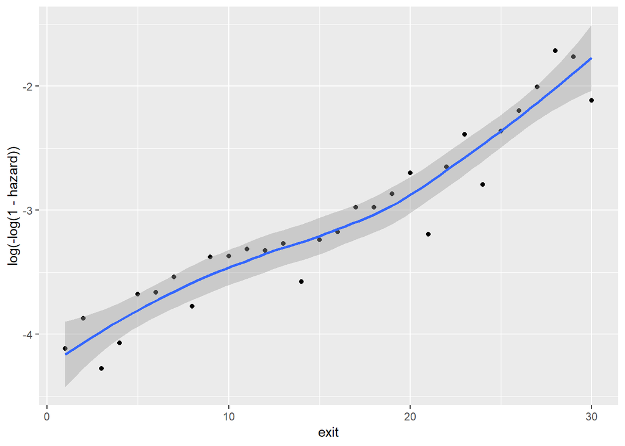

```r
Scania_PersonPeriod_Train %>%
  group_by(exit) %>%
  summarise(event = sum(event),
            total = n()) %>%
  mutate(hazard = event/total) %>%
  ggplot(aes(x = exit, y = log(-log(1-hazard)))) +
  geom_point() +
  geom_smooth()
```

We can see that the relationship between time (`exit`) and the cloglog(hazard) is almost a linear straight line. Therefore, we set up the baseline model by specifying a single linear term for $\gamma_{0s}$. See below.

Note that the specification of a Gompertz model is similar to a binary logistic regression model (using the `glm` function). The only difference is that we need to set the link function as “cloglog”.

```r
Gompertz_Model_Baseline <- glm(formula = event ~ exit,
                               family = binomial(link = "cloglog"),
                               data = Scania_PersonPeriod_Train)

summary(Gompertz_Model_Baseline)
```

```
##
## Call:
## glm(formula = event ~ exit, family = binomial(link = "cloglog"),
##     data = Scania_PersonPeriod_Train)
##
## Deviance Residuals:
##     Min       1Q   Median       3Q      Max
## -0.5262  -0.3105  -0.2386  -0.1976   2.8879
##
## Coefficients:
##              Estimate Std. Error z value Pr(>|z|)
## (Intercept) -4.237533   0.073795  -57.42   <2e-16 ***
## exit         0.075346   0.004202   17.93   <2e-16 ***
## ---
## Signif. codes:  0 '***' 0.001 '**' 0.01 '*' 0.05 '.' 0.1 ' ' 1
##
## (Dispersion parameter for binomial family taken to be 1)
##
##     Null deviance: 7211.1  on 22334  degrees of freedom
## Residual deviance: 6897.5  on 22333  degrees of freedom
## AIC: 6901.5
##
## Number of Fisher Scoring iterations: 6
```

From the model summary above, we can see a significant and positive relationship between `exit` and hazard. This baseline effect of time (i.e. `exit`) on hazards is the same for all individuals and changes only with regards to time (i.e. `exit`). For instance, at time point 30 (`exit` = 30) (which means that the person’s age is about 80), the baseline hazard for all individuals is: 1-exp(-exp(-4.237533+0.075346*30)) = 0.13. This means that at age 80, the probability (hazard) of dying for an individual in that year (without factoring in any other information) is 0.13.

To ease the interpretaion, we can exponentiate the model estimates, using the `summ` function from the `jtools` package.

```r
summ(Gompertz_Model_Baseline, exp = T)
```

```
## MODEL INFO:
## Observations: 22335
## Dependent Variable: event
## Type: Generalized linear model
##   Family: binomial
##   Link function: cloglog
##
## MODEL FIT:
## χ²(1) = 313.55, p = 0.00
## Pseudo-R² (Cragg-Uhler) = 0.05
## Pseudo-R² (McFadden) = 0.04
## AIC = 6901.51, BIC = 6917.53
##
## Standard errors: MLE
##
## |            | exp(Est.)| 2.5%| 97.5%| z val.|    p|
## |:-----------|---------:|----:|-----:|------:|----:|
## |(Intercept) |      0.01| 0.01|  0.02| -57.42| 0.00|
## |exit        |      1.08| 1.07|  1.09|  17.93| 0.00|
```

An estimate of 1.08 means that, for one unit increase in `exit` (i.e. one additional observed year for a person), the probability (i.e. hazard) of the person dying, given that he/she survived the last time period, increases by 8%.

#### 5.2. Fit a Full Gompertz Regression Model

To answer the research question (i.e. What are the effects of gender, socio-economic status, immigrant status, and food prices on a person’s conditional probability of dying during a given time interval?), we would want to fit a Gompertz regression model that includes all the variables of interest (i.e. `sex`, `ses`, `immigrant` and `foodprices`). Before we specify the model, it might be interesting to also visually examine the relationship between these variables and cloglog(hazard).

Between `sex` and cloglog(hazard):

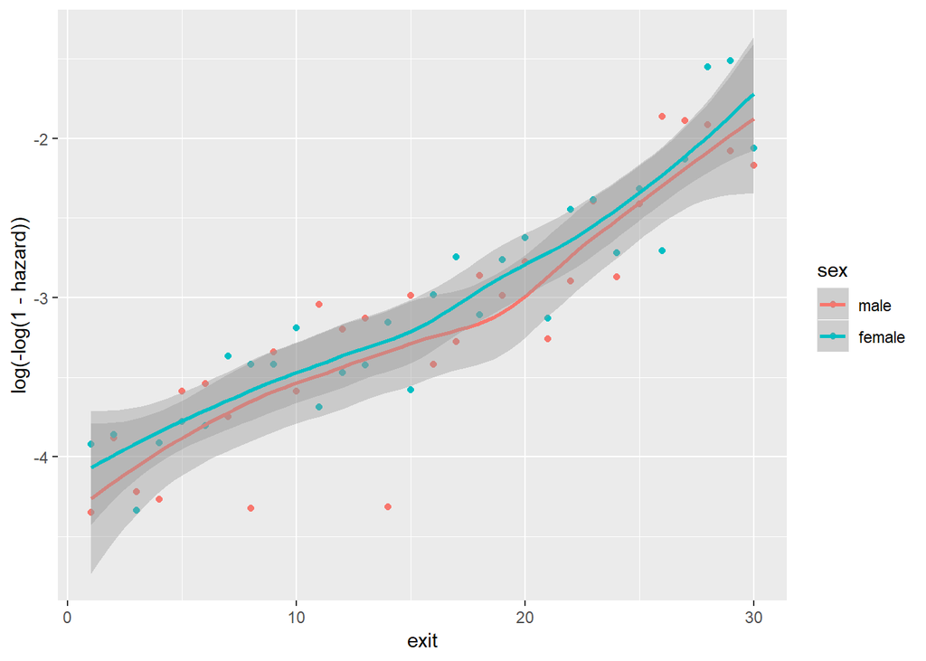

```r
Scania_PersonPeriod_Train %>%
  group_by(exit, sex) %>%
  summarise(event = sum(event),
         total = n()) %>%
  mutate(hazard = event/total) %>%
  ggplot(aes(x = exit,
             y = log(-log(1-hazard)),
             col = sex)) +
  geom_point() +
  geom_smooth()
```

Between `ses` and cloglog(hazard):

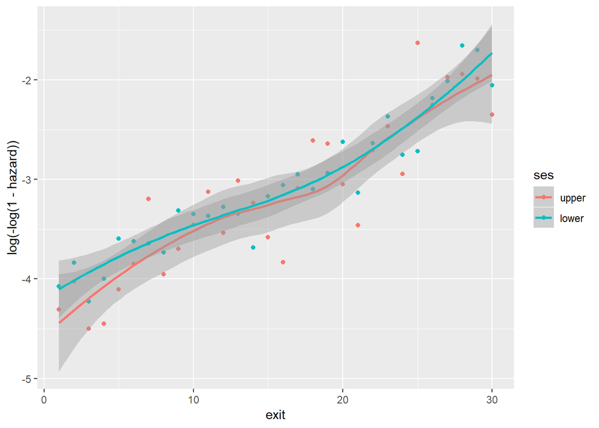

```r
Scania_PersonPeriod_Train %>%
  group_by(exit, ses) %>%
  summarise(event = sum(event),
         total = n()) %>%
  mutate(hazard = event/total) %>%
  ggplot(aes(x = exit,
             y = log(-log(1-hazard)),
             col = ses)) +
  geom_point() +
  geom_smooth()
```

Between `immigrant` and cloglog(hazard):

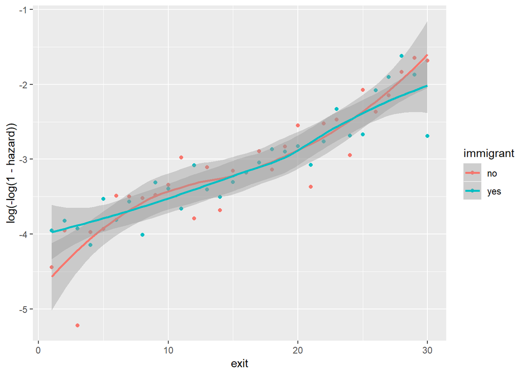

```r
Scania_PersonPeriod_Train %>%
  group_by(exit, immigrant) %>%
  summarise(event = sum(event),
         total = n()) %>%
  mutate(hazard = event/total) %>%
  ggplot(aes(x = exit,
             y = log(-log(1-hazard)),
             col = immigrant)) +
  geom_point() +
  geom_smooth()
```

Between `foodprices` and cloglog(hazard):

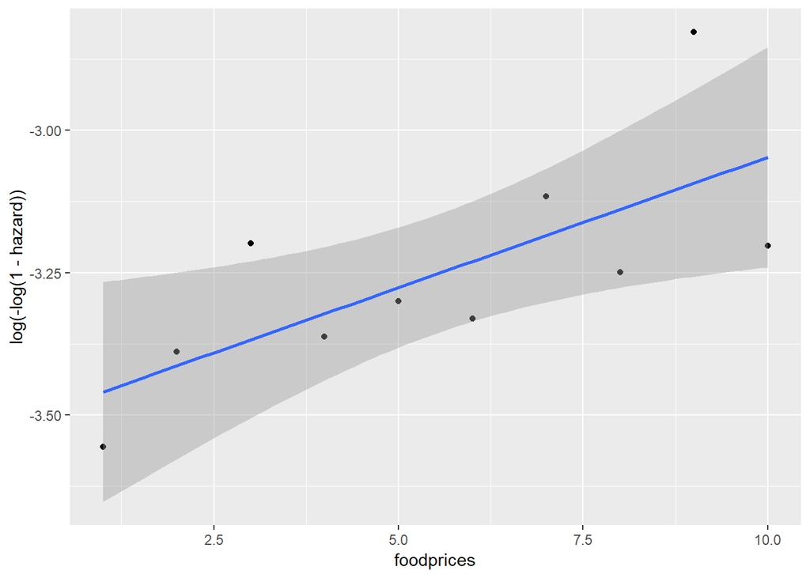

```r
Scania_PersonPeriod_Train %>%
  mutate(foodprices = cut_interval(foodprices, 10, labels = F)) %>%
  group_by(foodprices) %>%
  summarise(event = sum(event),
            total = n()) %>%
  mutate(hazard = event/total) %>%
  ggplot(aes(x = foodprices, y = log(-log(1-hazard)))) +
  geom_point() +
  geom_smooth(method = "lm")
```

Note that because `foodprices` is a continous variable, we cut it into 10 intervals of equal lengths (indicated by 1 through 10). As we can see, at almost any given point in time (`exit`), different groups of the `sex`, `ses` and `immigrant` variables, respectively, have similar cloglog(hazard) values, indicated by the largely overlapped uncertainty regions. Therefore, it is unlikely that these three variables contribute to the prediction of hazards on top of the baseline intercept term (`exit`). On the other hand, `foodprices` seems to be positively and linearly related to cloglog(hazard).

Now we fit the full model with all the variables just examined.

```r
Gompertz_Model_Full <- glm(formula = event ~ exit + sex + ses + immigrant + foodprices,
                           family = binomial(link = "cloglog"),
                           data = Scania_PersonPeriod_Train)

summary(Gompertz_Model_Full)
```

```
##
## Call:
## glm(formula = event ~ exit + sex + ses + immigrant + foodprices,
##     family = binomial(link = "cloglog"), data = Scania_PersonPeriod_Train)
##
## Deviance Residuals:
##     Min       1Q   Median       3Q      Max
## -0.5822  -0.3055  -0.2356  -0.1961   2.9381
##
## Coefficients:
##               Estimate Std. Error z value Pr(>|z|)
## (Intercept)  -4.306098   0.112021 -38.440  < 2e-16 ***
## exit          0.075387   0.004205  17.929  < 2e-16 ***
## sexfemale     0.077144   0.069053   1.117  0.26392
## seslower      0.036178   0.086316   0.419  0.67512
## immigrantyes -0.009161   0.069502  -0.132  0.89514
## foodprices    0.549623   0.206521   2.661  0.00778 **
## ---
## Signif. codes:  0 '***' 0.001 '**' 0.01 '*' 0.05 '.' 0.1 ' ' 1
##
## (Dispersion parameter for binomial family taken to be 1)
##
##     Null deviance: 7211.1  on 22334  degrees of freedom
## Residual deviance: 6888.9  on 22329  degrees of freedom
## AIC: 6900.9
##
## Number of Fisher Scoring iterations: 6
```

Confirming our previous visual observations, `ses`, `ses`, and `immigrant` do not significantly predict the outcome, while `exit` and `foodprices` are significantly and positively related to hazards. To ease the interpretation, we exponentiate the estimates:

```r
summ(Gompertz_Model_Full, exp = T)
```

```
## MODEL INFO:
## Observations: 22335
## Dependent Variable: event
## Type: Generalized linear model
##   Family: binomial
##   Link function: cloglog
##
## MODEL FIT:
## χ²(5) = 322.18, p = 0.00
## Pseudo-R² (Cragg-Uhler) = 0.05
## Pseudo-R² (McFadden) = 0.04
## AIC = 6900.88, BIC = 6948.96
##
## Standard errors: MLE
##
## |             | exp(Est.)| 2.5%| 97.5%| z val.|    p|
## |:------------|---------:|----:|-----:|------:|----:|
## |(Intercept)  |      0.01| 0.01|  0.02| -38.44| 0.00|
## |exit         |      1.08| 1.07|  1.09|  17.93| 0.00|
## |sexfemale    |      1.08| 0.94|  1.24|   1.12| 0.26|
## |seslower     |      1.04| 0.88|  1.23|   0.42| 0.68|
## |immigrantyes |      0.99| 0.86|  1.14|  -0.13| 0.90|
## |foodprices   |      1.73| 1.16|  2.60|   2.66| 0.01|
```

`foodprices` seems to have a very strong effect on the outcome hazards. For one unite increase in food prices, a person’s probabilty (hazard) of dying is increased by 73%, at any given time point. However, note that the range of `foodprices` is only between -0.40 and 0.40; it is, therefore, impossible that `foodprices` increases by 1. Because of this, it makes more sense to interpret the standardised estimates by setting `scale = T`:

```r
summ(Gompertz_Model_Full, exp = T, scale = T)
```

```
## MODEL INFO:
## Observations: 22335
## Dependent Variable: event
## Type: Generalized linear model
##   Family: binomial
##   Link function: cloglog
##
## MODEL FIT:
## χ²(5) = 322.18, p = 0.00
## Pseudo-R² (Cragg-Uhler) = 0.05
## Pseudo-R² (McFadden) = 0.04
## AIC = 6900.88, BIC = 6948.96
##
## Standard errors: MLE
##
## |            | exp(Est.)| 2.5%| 97.5%| z val.|    p|
## |:-----------|---------:|----:|-----:|------:|----:|
## |(Intercept) |      0.03| 0.03|  0.04| -37.93| 0.00|
## |exit        |      1.77| 1.66|  1.88|  17.93| 0.00|
## |sex         |      1.08| 0.94|  1.24|   1.12| 0.26|
## |ses         |      1.04| 0.88|  1.23|   0.42| 0.68|
## |immigrant   |      0.99| 0.86|  1.14|  -0.13| 0.90|
## |foodprices  |      1.10| 1.02|  1.18|   2.66| 0.01|
##
## Continuous predictors are mean-centered and scaled by 1 s.d.
```

Now, we know that hazards increase by 10% with a standard deviation increase in `foodprices`, assuming everything else stays constant.

#### 5.3. Visualisation of Parameter Effects

To make the interpretation of the parameter effects even easier, we can use the `plot_summs` function from the `joots` package. It is useful to set `exp = T` and `scale = T`, so that we can exponentiated standardised estimates that are easier to interprete than the raw numbers.

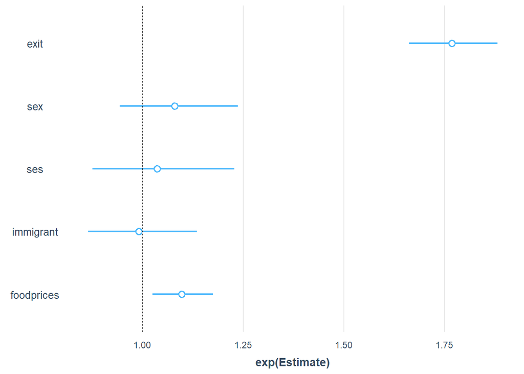

```r
plot_summs(Gompertz_Model_Full, exp = T, scale = T)
```

Now we can see that the strongest predictor of the outcome is `exit`, followed by `foodprices`. In contrast, `sex`, `ses`, and `immigrant` are unlikely important predictors because their uncertainty intervals overlap with 1, which indicates likely no effect.

Alternatively, we can use the `allEffects` function from the `effects` package to visualise the parameter effects. See below.

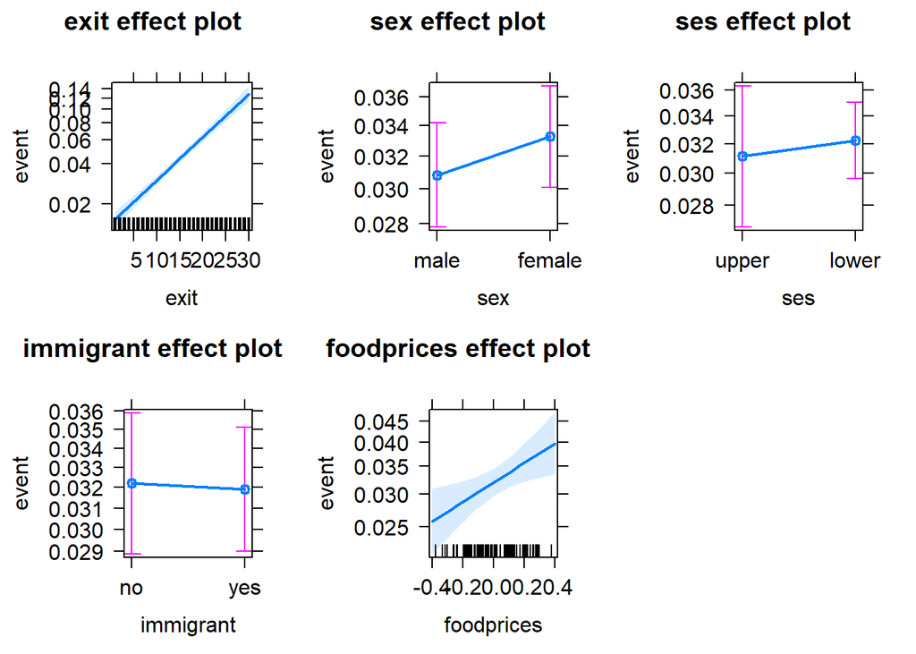

```r
plot(allEffects(Gompertz_Model_Full))
```

Note that in these plots, the y scales refer to the predicted hazards (probability of death). Such plots are helpful when the model uses a link (e.g. logit) that results in less interpretable model estimates, because probabilities (hazards) are more interpretable than, for example, odds. The probability scores for each variable are calculated by assuming that the other variables in the model are constant and take on their average values. Note that the confidence intervals for the estimates are also included to give us some idea of the uncertainties.

Note that the notion of average `ses`, `sex` and `immigrant` may sound strange, given they are categorical variables (i.e. factors). If you are not comfortable with the idea of assuming an average factor, you can specify your intended factor level as the reference point, by using the `fixed.predictors = list(given.values = ...)` argument in the allEffects function. See below:

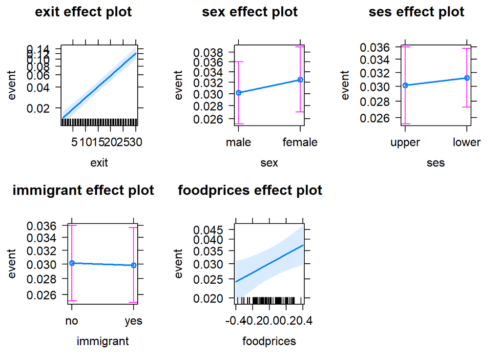

```r
plot(allEffects(Gompertz_Model_Full,
                fixed.predictors = list(given.values=c(sexfemale=0,
                                                       seslower = 0,
                                                       immigrantyes = 0))))
```

Setting `sexfemale = 0` means that the reference level of the `sex` variable is set to 0 (=male); `seslower = 0` means that the reference level of the `ses` variable is set to 0 (=upper); `immigrantyes = 0` means that the reference level of the `immigrant` variable is set to 0 (=no).

## **6. Model Evaluation: Goodness of Fit**

We introduce here some common tests that we can use to examine the goodness-of-fit of a discrete-time survival model, including the likelihood ratio test, Akaike information criterion (AIC) and deviance residuals.

##### 6.1. Likelihood Ratio Test

A model has a better fit to the data if the model, compared with a model with fewer predictors, demonstrates an improvement in the fit. This is performed using the *likelihood ratio test*, which compares the likelihood of the data under the full model against the likelihood of the data under a model with fewer predictors. Removing predictor variables from a model will almost always make the model fit less well (i.e. a model will have a lower log likelihood), but it is useful to test whether the observed difference in model fit is statistically significant. In this way, the likelihood ratio test can also be used to determine the relevance of (a group of) variables. As an example, we can test whether our full Gompertz model provides a better fit to the data than the baseline Gompertz model, using the likelihood ratio test. This is done via the `anova` function.

```r
anova(Gompertz_Model_Baseline, Gompertz_Model_Full, test ="Chisq")
```

|  | Resid. Df | Resid. Dev | Df | Deviance | Pr(>Chi) |
| --- | --- | --- | --- | --- | --- |
| 1 | 22333 | 6897.505 | NA | NA | NA |
| 2 | 22329 | 6888.877 | 4 | 8.62823 | 0.07109428 |

As we can see, the difference between the two models is not significant at 5% level. Therefore, the inclusion of all of the additional predictors (`ses`, `sex`, `immigrant` and `foodprices`) does not provide a significantly better fit to the data.

##### 6.2. AIC

The Akaike information criterion (AIC) is another measure for model selection. Different from the likelihood ratio test, the calculation of AIC not only regards the goodness of fit of a model, but also takes into account the simplicity of the model. In this way, AIC deals with the trade-off between goodness of fit and complexity of the model, and as a result, disencourages overfitting. A smaller AIC is preferred.

```r
Gompertz_Model_Full$aic
```

```
## [1] 6900.877
```

```r
Gompertz_Model_Baseline$aic
```

```
## [1] 6901.505
```

The two models have extremely similar AIC scores, suggesting that their model fit performances are not well differentiated from each other.

##### 6.3. Deviance Residuals

Deviance residuals of a discrete-time survival model can be used to examine the fit of a model on a case-by-case manner. The deviance residual for each individual $i$ at time $s$ is calculated via the following formula:

$$DevRes_{is} = \begin{cases}-\sqrt{-2log(1-\hat{h}_{is})} & y_{is} = 0\\\sqrt{-2log(\hat{h}_{is})} & y_{is} = 1\end{cases}$$
From the formula we can see that the deviance residual is positive only if, and when, the event occurs. In contrast, deviance residuals are negative in all the time periods before event occurrence and remain negative in the final period for people who have not experienced the target event.

Unlike regular residuals, with deviance residuals we do not examine their distribution nor plot them versus predicted outcome or observed predictor values. We eschew such displays because they will manifest uninformative deterministic patterns. Instead, we examine deviance residuals on a case-by-case basis, generally through the use of *index plots*: sequential plots by case ID. When examining index plots like these, we look for extreme observations, namely person-period records with extraordinarily large residuals. Large residuals suggest person-period records with poor model fit.

Below we calculate the deviance residuals of the Gompertz full model and make the index plot:

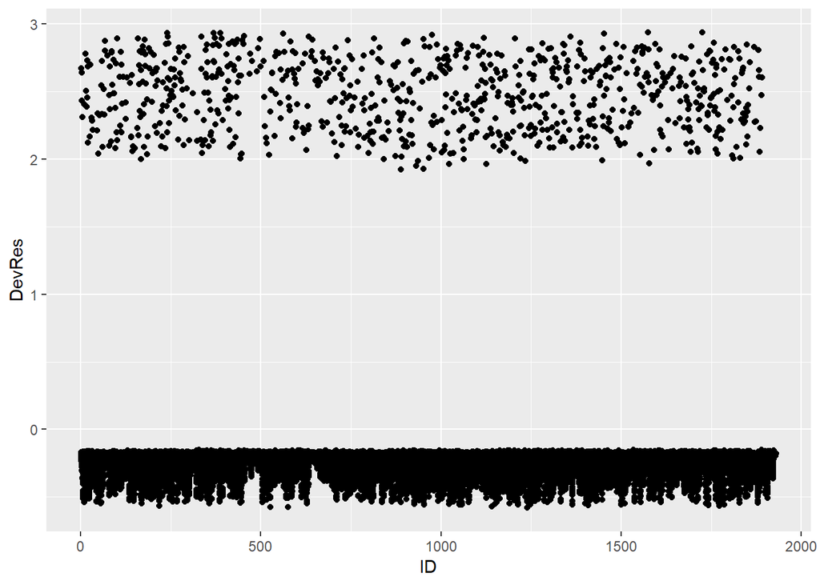

```r
Data_DevResid <- tibble(Pred_Haz = predict(Gompertz_Model_Full, type = "response"),
       Event = pull(Scania_PersonPeriod_Train, event),
       ID = pull(Scania_PersonPeriod_Train, id)) %>%
  mutate(DevRes = if_else(Event == 0,
                          -sqrt(-2*log(1-Pred_Haz)),
                          sqrt(-2*log(Pred_Haz))))
Data_DevResid %>%
  ggplot(aes(x = ID, y = DevRes)) +
  geom_point()
```

We see no substantially large and outlying residuals (>3 or <-3). However, we also notice that the deviance residiuals of the cases with event occurring are concentrated between 2 and 3, which are relatively far away from 0. In contrast, the cases without event occurring have residuals that are close to 0. This indicates that the model does not provide a good fit to the cases with event occurring.

## **7. Model Evaluation: Predictive Performance**

We have considered several methods for assessing the goodness-of-fit of a discrete-time survival model. They provide information about whether a model is well calibrated. In addition to assessing goodness-of-fit, it is often also our interest to measure the performance of a model with regards to predicting survival or hazards of future observations. We introduce here two such methods: **predictive deviance** and **prediction error curves** and apply them to the test data.

##### 7.1. Predictive Deviance

The formula for predictive deviance is as follows:

$$PD = -2\sum_{i=1}^n\sum_{s=1}^{t_{i}} y_{is}\log (\hat{h}_{is}) + (1-y_{is})\log (1-\hat{h}_{is})$$

The predictive deviance score for the full Gompertz model is computed via the following codes.

```r
#observed hazards
Obs_Haz <- pull(Scania_PersonPeriod_Test, event)

#predicted hazards
Pred_Haz_Full <- predict(Gompertz_Model_Full, Scania_PersonPeriod_Test, type = "response")

#predictive deviance
Pred_Dev_Full <- tibble(obs = Obs_Haz, pred = Pred_Haz_Full) %>%
  mutate(dev = obs*log(pred) + (1-obs)*log(1-pred)) %>%
  summarise(deviance = -2*sum(dev))%>%
  pull(deviance)

Pred_Dev_Full
```

```
## [1] 1878.409
```

We get a predictive deviance score of 1878.409 for the full model. This score itself is not informative, unless it is compared with the score of another model (based on the same data). We can calculate the predictive deviance score of the baseline Gompertz model.

```r
#observed hazards
Obs_Haz <- pull(Scania_PersonPeriod_Test, event)

#predicted hazards
Pred_Haz_Baseline <- predict(Gompertz_Model_Baseline, Scania_PersonPeriod_Test, type = "response")

#predictive deviance
Pred_Dev_Baseline <- tibble(obs = Obs_Haz, pred = Pred_Haz_Baseline) %>%
  mutate(dev = obs*log(pred) + (1-obs)*log(1-pred)) %>%
  summarise(deviance = -2*sum(dev))%>%
  pull(deviance)

Pred_Dev_Baseline
```

```
## [1] 1872.052
```

With the slightly smaller predictive deviance score, the baseline model predicts future observations better than does the full model. This suggests that the full model likely overfits the data.

##### 7.2. Prediction Error Curves

Prediction Error (PE) curves ($PE(t)$) are a time-dependent measure of prediction error based on the squared distance between the predicted individual survival functions $\hat{S}_{is} = \prod_{s=1}^t (1-\hat{h}_{is})$, and the corresponding observed survival functions $\tilde{S}_{is} = I(s < T_{i})$, where $I(.)$ denotes the indicator function, such that the observed survival functions are equal to 1 as long as an observation is still alive and become 0 after the event of interest has occurred. For each time point $s$ under consideration, the PE curves measure the deviation of what we observe (i.e., $\tilde{S}_{is}$) from what is predicted from a statistical model (i.e., $\hat{S}_{is}$). The PE curves in addition use inverse probability of censoring weights to account for biases due to censoring. The PE curve becomes small if the predicted survival functions agree closely with the observed survival functions. A well-predicting survival model should result in PE values that are smaller than 0.25 for all $s$. This is because 0.25 corresponds to the value of the PE curve obtained from a non-informative model with $\hat{S}_{is} = 0.5$ for all time points.

To calculate PE curves, we can borrow the `predErrDiscShort` function from the `discSurv` package. See below how to use the function to calculate the PE curves for the full model. Note that the `predErrDiscShort` function may take a while (up to several minutes) to run.

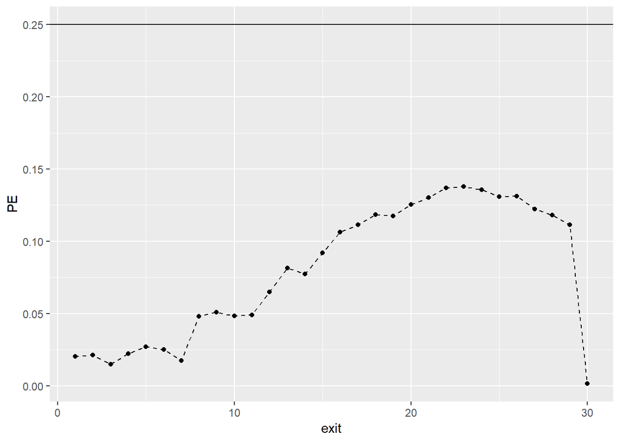

```r
#calculate 1 - predicted hazards
OneMinusPredHaz <- 1 - predict(Gompertz_Model_Full,
                               newdata = Scania_PersonPeriod_Test,
                               type = "response")
#calculate individual predicted survival curves
PredSurv <- aggregate(formula = OneMinusPredHaz ~ id,
                      data = Scania_PersonPeriod_Test,
                      FUN=cumprod)

#PE curves for all the 30 time points in the data
PredErrCurve <- predErrDiscShort(timepoints = 1:30,
                                 estSurvList = PredSurv[[2]], #survival curves
                                 newTime = Scania_Person_Test$exit, #time points in the test set
                                 newEvent = Scania_Person_Test$event, #event in the test set
                                 trainTime = Scania_Person_Train$exit, #time points in the training set
                                 trainEvent = Scania_Person_Train$event) #event in the training set
#plot the PE curve
tibble(PE = PredErrCurve$Output$predErr) %>%
  mutate(exit = row_number()) %>%
  ggplot(aes(y = PE, x = exit)) +
  geom_point() +
  geom_line(lty = "dashed") +
  geom_hline(yintercept = 0.25)
```

As we can see, all points of the curve stay consistently well below the cut-off value of 0.25. Therefore, the Gompertz full model predicts future survival substantially better than chance. Of course, we can also compare PE curves from competing models.

## **8. Multilevel Discrete-Time Survival Analysis**

In regression modelling, we try to include all relevant predictors. However, most often we have only access to a limited number of potentially influential variables. Because of this, part of the heterogeneity in the population remains unobserved. Unobserved heterogeneity can cause severe problems to especially survival modelling. For instance, with substantial unobserved heterogeneity, the parameter effects that we observe in the model only apply on the population level, but not on the individual level. Multilevel modelling helps to mitigate this issue. The most basic application of multilevel modelling in survival analysis is the so-called **basic frailty model**, where we assume that every individual has its own hazard function. We do so by introducing a random intercept term.

In R, we can use the `lme4` package to specify multilevel discrete-time survival regression models. See below as an example of how to specify the basic frailty model. For a detailed introduction to multilevel models with `lme4`, check out the tutorial [Lme4 introduction (frequentist)](https://www.rensvandeschoot.com/tutorials/lme4).

```r
library(lme4)
Model_Multi <- glmer(formula = event ~ exit + sex + ses + immigrant + foodprices + (1|id),
                     family = binomial(cloglog),
                     data = Scania_PersonPeriod_Train,
                     control = glmerControl(optimizer = "bobyqa",
                                            optCtrl = list(maxfun = 2e5)))
```

```
## boundary (singular) fit: see ?isSingular
```

```r
summary(Model_Multi)
```

```
## Generalized linear mixed model fit by maximum likelihood (Laplace
##   Approximation) [glmerMod]
##  Family: binomial  ( cloglog )
## Formula: event ~ exit + sex + ses + immigrant + foodprices + (1 | id)
##    Data: Scania_PersonPeriod_Train
## Control:
## glmerControl(optimizer = "bobyqa", optCtrl = list(maxfun = 2e+05))
##
##      AIC      BIC   logLik deviance df.resid
##   6902.9   6959.0  -3444.4   6888.9    22328
##
## Scaled residuals:
##     Min      1Q  Median      3Q     Max
## -0.4297 -0.2186 -0.1678 -0.1393  8.5971
##
## Random effects:
##  Groups Name        Variance Std.Dev.
##  id     (Intercept) 0        0
## Number of obs: 22335, groups:  id, 1545
##
## Fixed effects:
##               Estimate Std. Error z value Pr(>|z|)
## (Intercept)  -4.306098   0.112043 -38.433  < 2e-16 ***
## exit          0.075387   0.004212  17.900  < 2e-16 ***
## sexfemale     0.077144   0.069079   1.117  0.26410
## seslower      0.036177   0.086375   0.419  0.67533
## immigrantyes -0.009161   0.069518  -0.132  0.89516
## foodprices    0.549623   0.206695   2.659  0.00784 **
## ---
## Signif. codes:  0 '***' 0.001 '**' 0.01 '*' 0.05 '.' 0.1 ' ' 1
##
## Correlation of Fixed Effects:
##             (Intr) exit   sexfml seslwr immgrn
## exit        -0.604
## sexfemale   -0.254  0.001
## seslower    -0.575  0.017 -0.099
## immigrantys -0.331  0.026 -0.010 -0.057
## foodprices  -0.039  0.004 -0.005  0.007  0.007
## convergence code: 0
## boundary (singular) fit: see ?isSingular
```

Note that the basic frailty model has a negative log-likelihood of -3444.4 and an AIC of 6902.9. In comparison, the previous Gompertz model without the person-level frailty term has a negative log-likelihood of -3444.438 and AIC of 6900.877. The almost identical log-likelihood scores and AIC scores between the two models suggests that there is no need for a frailty model.

This model does not delve deeper into multilevel extensions of discrete-time survival regression. For this specific topic, please see Chapter 9 of [Modeling Discrete Time-to-Event Data](https://www.springer.com/gp/book/9783319281568) by Tutz & Schmid (2016). For more multilevel modelling in general, check out [Multilevel analysis: Techniques and applications](https://www.rensvandeschoot.com/multilevel-book/). For introduction to GLM or multilevel modelling in R, see the relevant tutorials on [Online Stats Training](https://www.rensvandeschoot.com/tutorials/).

## **9. Bayesian Discrete-Time Survival Analysis**

If you would like to work with the Bayesian framework for discrete-time survival analysis (multilevel or not), you can use the `brms` package in R. As discrete-time regression analysis uses the glm framework, if you know how to use the `brms` package to set up a Bayesian generalised linear model, you are good to go. For this, check out the relevant tutorials on [Online Stats Training](https://www.rensvandeschoot.com/tutorials/), such as **BRMS getting started** and **Intro to Bayesian (Multilevel) Generalised Linear Models (GLM) in R with brms**. We also recommend that you follow the [WAMBS-checklist](https://www.rensvandeschoot.com/wambs-checklist/) if you do use the Bayesian approach in your research.

Below is an example of how to use the `brms` package to set up the previous Gompertz full model. Note that the estimates are almost the same as the model fitted by `glm`.

```r
library(brms)
Bayes_Model <- brm(formula = event ~ exit + sex + ses + immigrant + foodprices,
                   data = Scania_PersonPeriod_Train,
                   family = bernoulli(link = "cloglog"),
                   warmup = 500,
                   iter = 2000,
                   chains = 2,
                   inits= "0",
                   cores=2,
                   seed = 123)
Bayes_Model
```

```
##  Family: bernoulli
##   Links: mu = cloglog
## Formula: event ~ exit + sex + ses + immigrant + foodprices
##    Data: Scania_PersonPeriod_Train (Number of observations: 22335)
## Samples: 2 chains, each with iter = 2000; warmup = 500; thin = 1;
##          total post-warmup samples = 3000
##
## Population-Level Effects:
##              Estimate Est.Error l-95% CI u-95% CI Eff.Sample Rhat
## Intercept       -4.31      0.11    -4.53    -4.10       3473 1.00
## exit             0.08      0.00     0.07     0.08       3593 1.00
## sexfemale        0.08      0.07    -0.06     0.22       3477 1.00
## seslower         0.04      0.09    -0.12     0.21       3519 1.00
## immigrantyes    -0.01      0.07    -0.14     0.13       3829 1.00
## foodprices       0.55      0.21     0.15     0.95       5709 1.00
##
## Samples were drawn using sampling(NUTS). For each parameter, Eff.Sample
## is a crude measure of effective sample size, and Rhat is the potential
## scale reduction factor on split chains (at convergence, Rhat = 1).
```

## **Reference**

Bates, D., Maechler, M., Bolker, B., & Walker, S. (2015). *Fitting Linear Mixed-Effects Models Using lme4. Journal of Statistical Software, 67*(1), 1-48. [doi:10.18637/jss.v067.i01](https://doi.org/10.18637/jss.v067.i01)

Broström, G. (2018). eha: Event History Analysis. R package version 2.6.0. https://CRAN.R-project.org/package=eha

Fox, J. (2003). *Effect Displays in R for Generalised Linear Models. Journal of Statistical Software, 8*(15), 1-27. http://www.jstatsoft.org/v08/i15/

Long, JA. (2019). jtools: Analysis and Presentation of Social Scientific Data. R package version 2.0.1, https://cran.r-project.org/package=jtools

Lüdecke, D. (2019). sjstats: Statistical Functions for Regression Models (Version 0.17.5). [doi: 10.5281/zenodo.1284472](http://dx.doi.org/10.5281/zenodo.1284472)

Tutz, G., & Schmid, M. (2016). Modeling Discrete Time-to-Event Data (1st ed.). Springer New York. https://doi.org/10.1007/978-3-319-28158-2

Welchowski, T., & Schmid, M (2018). discSurv: Discrete Time Survival Analysis. R package version 1.3.4. https://CRAN.R-project.org/package=discSurv

Wickham, H. (2017). tidyverse: Easily Install and Load the ‘Tidyverse’. R package version 1.2.1. https://CRAN.R-project.org/package=tidyverse